# Investigating Mechanical Feedback

Axel Almet

26 October 2018

# Introduction

We investigate the effect of incorporating mechanical feedback into two material properties: growth and mechanical stiffness.

### Mechanical feedback in growth—additive or multiplicative?

In the literature, it has been shown that tension within epithelial tissue can promote tissue growth through proliferation, while excessive compression inhibits growth, which is generally referred to as contact inhibition. We consider a growth law that describes the regulation of growth. This can be incorporated in two different ways. Either, we say that the axial stress directly promotes or inhibits growth, described by the following law:
$$\begin{align}
\frac{\dot{\gamma}}{\gamma} = W(s) + \mu(n_3 - n_3^*),
\end{align}$$
or, we can say that axial stress modulates the effect of Wnt signalling on growth:
$$\begin{align}
\frac{\dot{\gamma}}{\gamma} = W(s)\left[1 + \mu(n_3 - n_3^*)\right].
\end{align}$$
In both equations, $n_3$ is the axial stress within the rod. To model the *relative* change in stress over time, we consider a remodelling equation for the target stress $n_3^*$,
$$\begin{align}
\dot{n_3^*} = \eta(n_3 - n_3^*).
\end{align}$$

Here, rather than prescribe $n_3^* = 0$, we set $n_3^*(0)$ to be the critical buckling stress, which can be determined from a linear stability analysis.

### Mechanical feedback

We consider mechanical feedback on mechanical stiffness, which has been shown to yield anisotropies in growth in plant tissue models. It has been shown that in order to maintain confluence, epithelial tissues can increase cell-cell adhesion when stretched, and decrease stiffness when compressed. We thus consider a stiffness feedback law of the form

$$\begin{align}
\dot{E_b} = \mu(n_3 - n_3^*),
\end{align}$$

# Results

### Effect of feedback sensitivity in growth

We plot the morphologies for mechanosensitive growth under a linear coupling, for varying sensitivity rates.

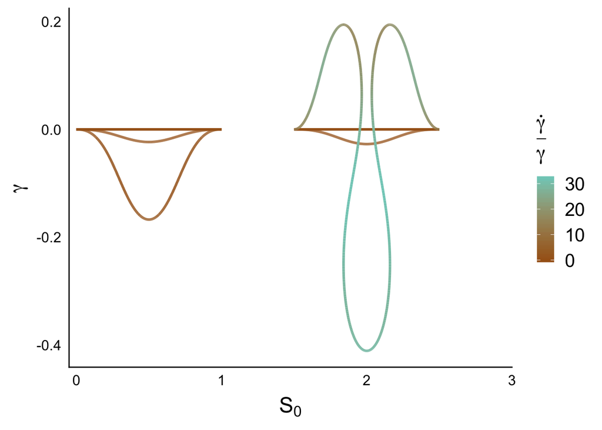

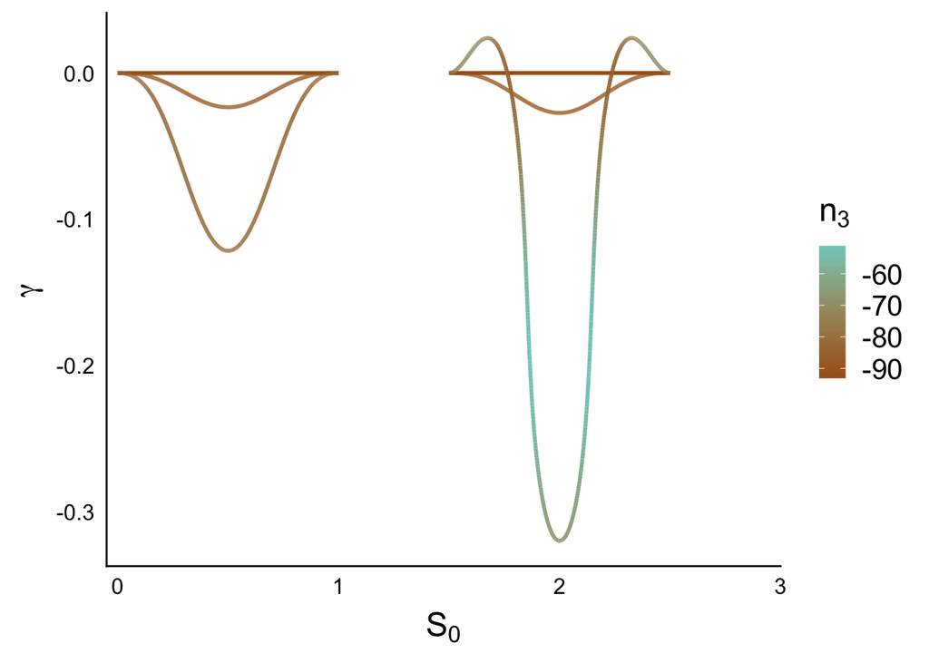

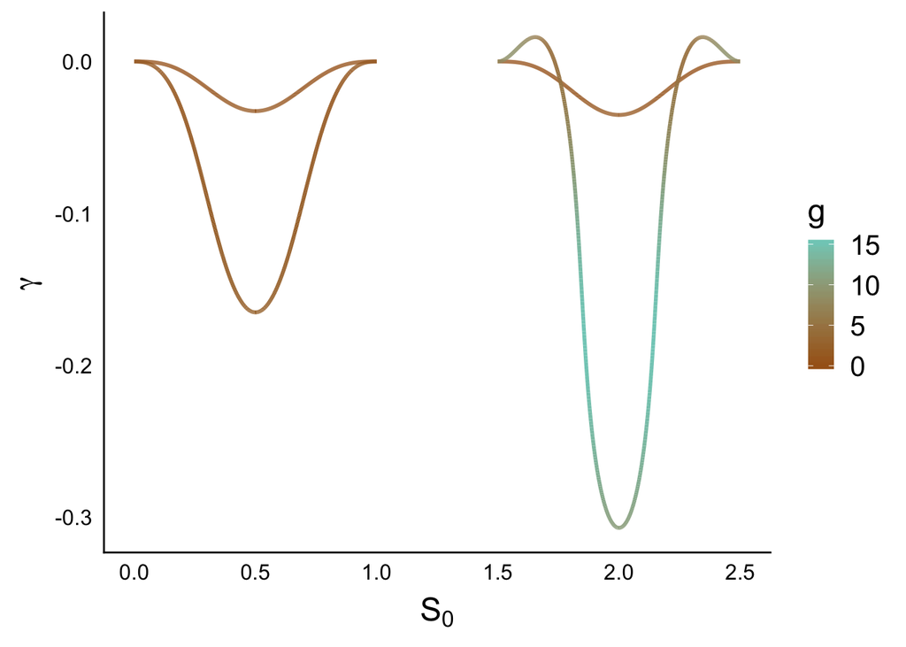

We now plot the same results but for saturating mechanosensitive growth:

$\frac{\dot{\gamma}}{\gamma} = W(s) + \mu\tanh\left(n_3 - n_3^*\right)$

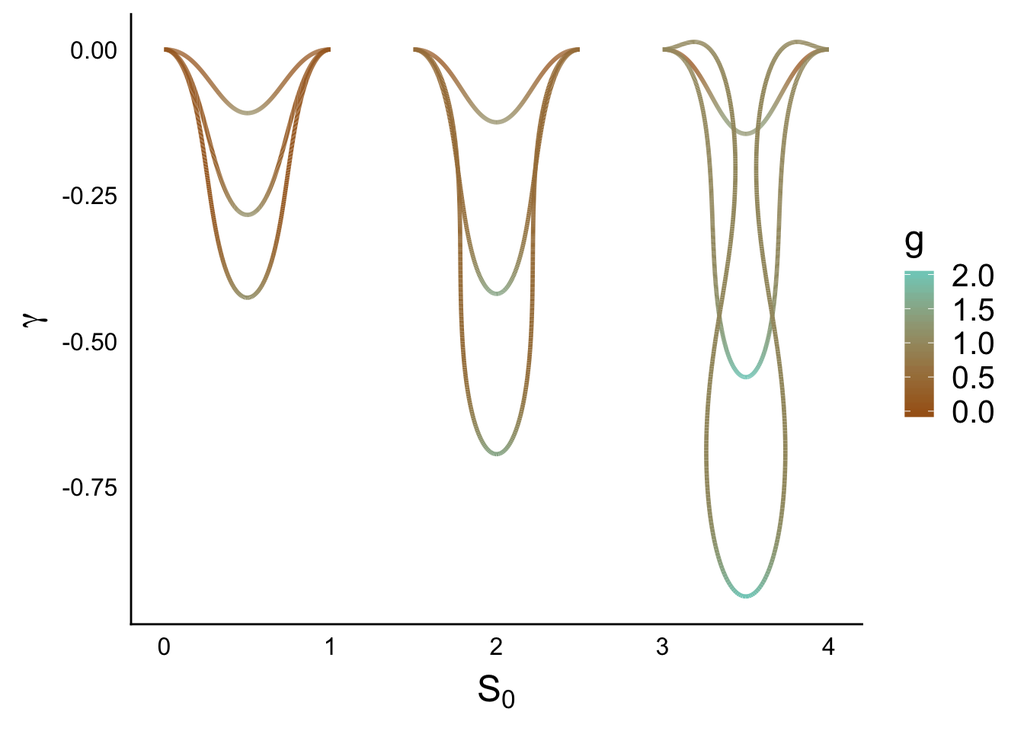

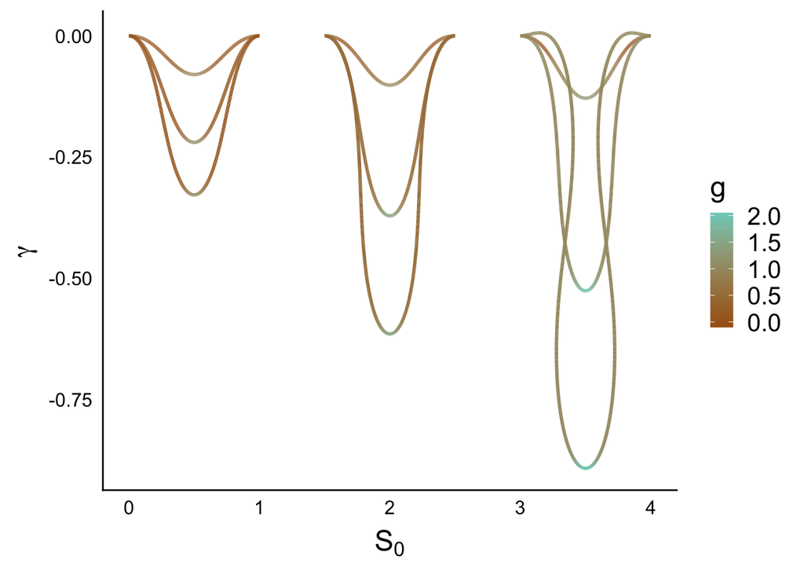